# POMA EDA Example

Pol Castellano-Escuder

Duke University

polcaes@gmail.com

1 November 2022

# Contents

**Compiled date**: 2022-11-01

**Last edited**: 2022-08-02

**License**: GPL-3

# 1 Installation

Run the following code to install the Bioconductor version of package.

```r
# install.packages("BiocManager")
BiocManager::install("POMA")
```

# 2 Load POMA

```r
library(POMA)
```

# 3 Automatic EDA Report

The following function will return an Exploratory Data Analysis (EDA) HTML report. The input object must be a **SummarizedExperiment** object.

```r
data("st000336")
PomaEDA(st000336)
```

**Generated EDA HTML report starts here.**

# 4 Know your data

- Your data have **57** samples, **31** features and **2** groups, that are **‘Controls’, ‘DMD’**. Furthermore, **1** covariates have been found in your data. These covariates are **‘steroids’**.
- A **3.45%** of values in your data are NAs (missing values). Variables that have NA values are **‘aspartic_acid (5)’, ‘citrulline (28)’, ‘glutamic_acid (15)’, ‘methionine (3)’, ‘x3_hba (1)’, ‘a_kg (1)’, ‘citrate (2)’, ‘fumarate (1)’, ‘lactate (2)’, ‘malate (1)’, ‘pyruvate (1)’, ‘succinate (1)’**.
- A **0%** of values in your data are zeros.
- Removed from the exploratory data analysis **0** features that only have zeros.
- Removed from the exploratory data analysis **0** features that have zero variance.

## 4.1 Summary Tables

```
  Samples Features Covariates
1      57       31          1
  Number_Zeros Percentage_Zeros
1            0              0 %
  Number_Missings Percentage_Missings
1              61              3.45 %
```

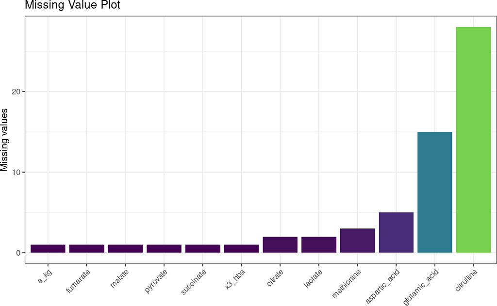

## 4.2 Samples by Group

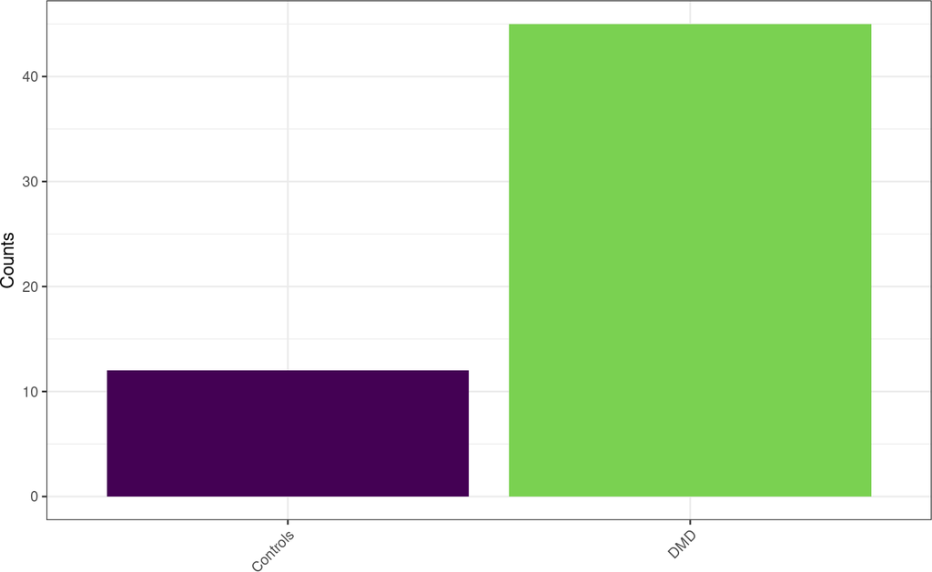

# 5 Normalization Plots

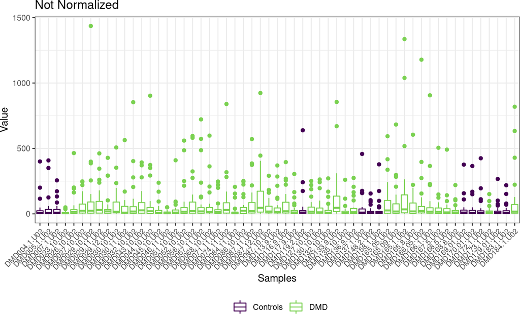

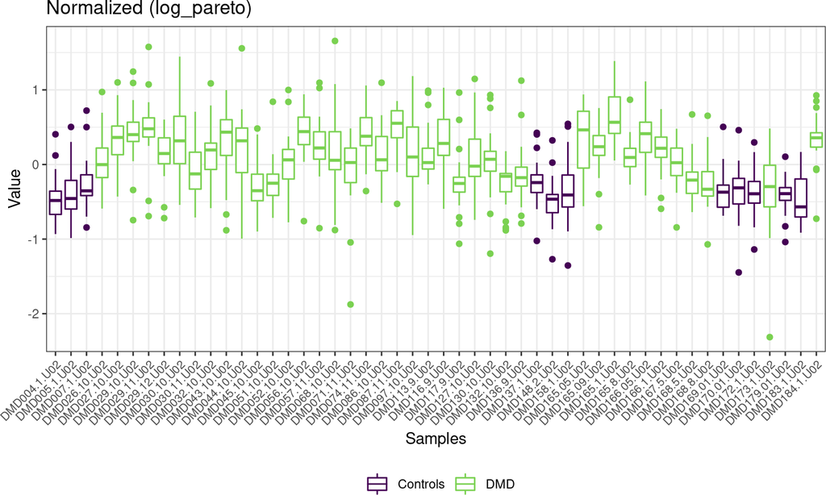

# 6 Group Distribution Plots

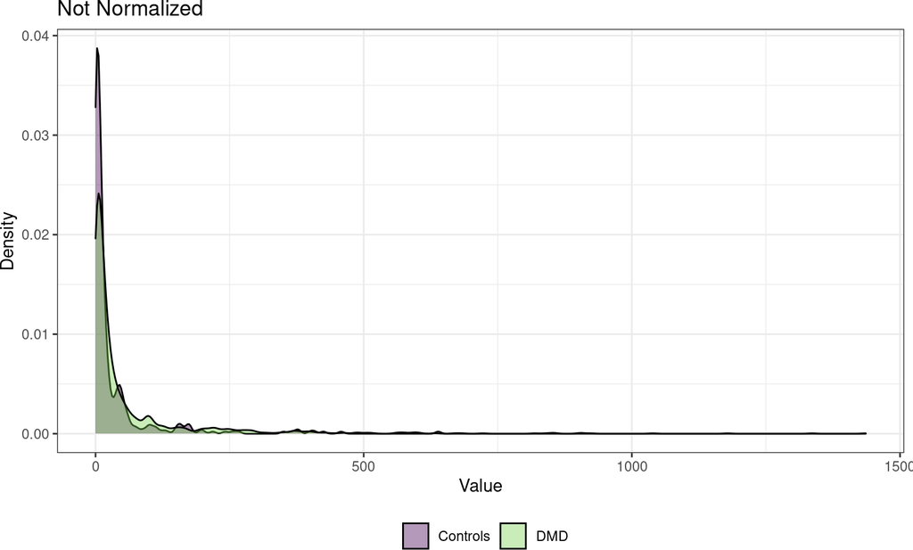

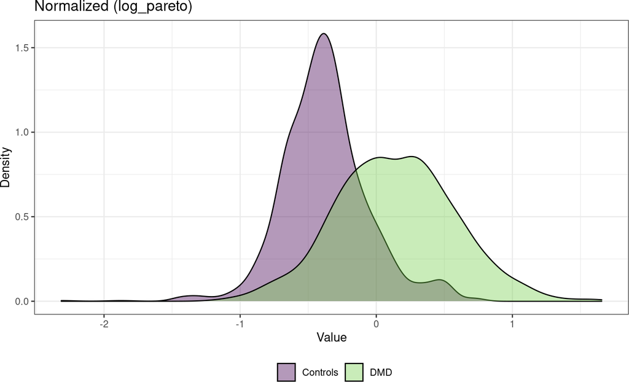

# 7 Outlier Detection

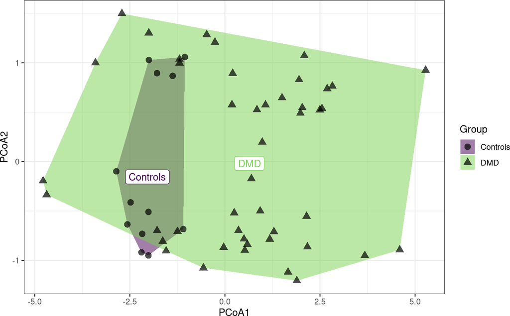

**7** possible outliers detected in your data. These outliers are **‘DMD119.2.U02’, ‘DMD084.11.U02’, ‘DMD087.12.U02’, ‘DMD023.10.U02’, ‘DMD046.11.U02’, ‘DMD133.9.U02’, ‘DMD135.10.U02’**.

```
# A tibble: 7 × 4
  sample        group    distance_to_centroid limit_distance
  <chr>         <fct>                   <dbl>          <dbl>
1 DMD119.2.U02  Controls                 2.74           2.29
2 DMD084.11.U02 DMD                      4.52           4.04
3 DMD087.12.U02 DMD                      4.25           4.04
4 DMD023.10.U02 DMD                      5.65           4.04
5 DMD046.11.U02 DMD                      5.58           4.04
6 DMD133.9.U02  DMD                      5.35           4.04
7 DMD135.10.U02 DMD                      4.06           4.04
```

# 8 High Correlated Features (r > 0.97)

There are **0** high correlated feature pairs in your data.

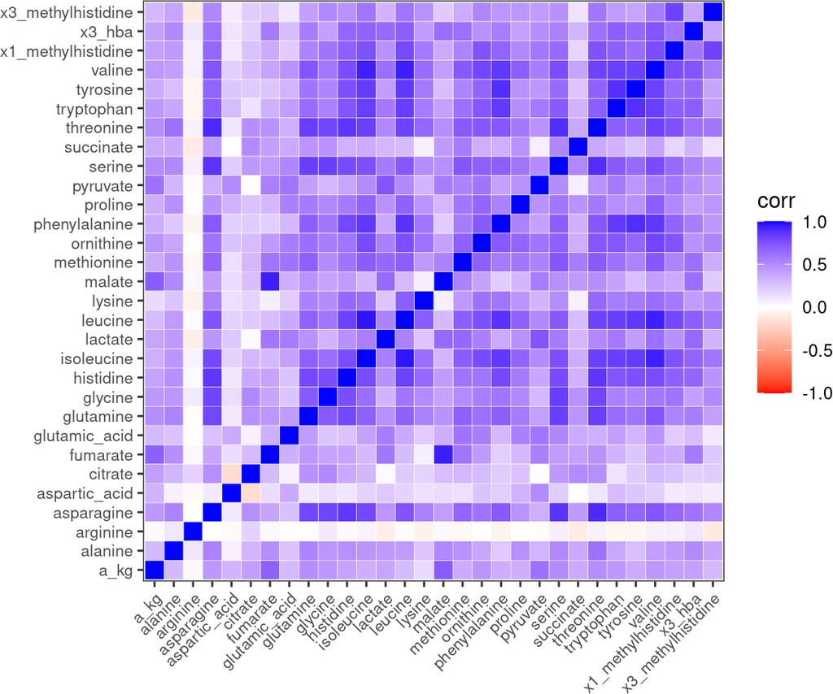

# 9 Heatmap and Clustering

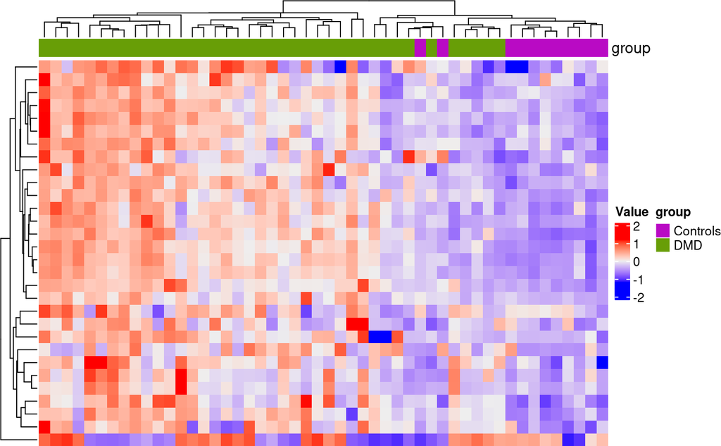

# 10 Principal Component Analysis

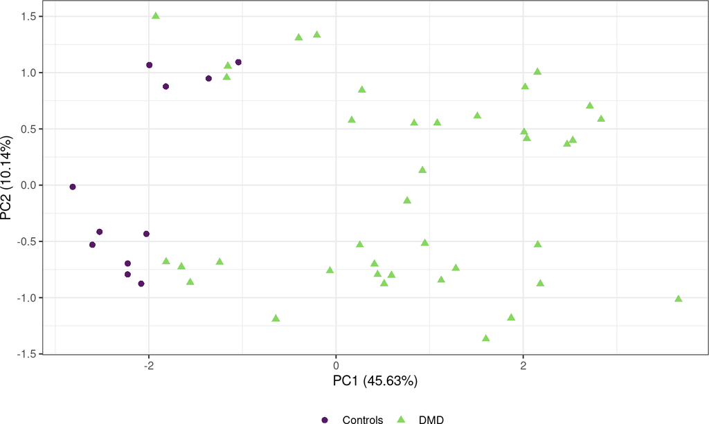

# 11 Uniform Manifold Approximation and Projection Clustering

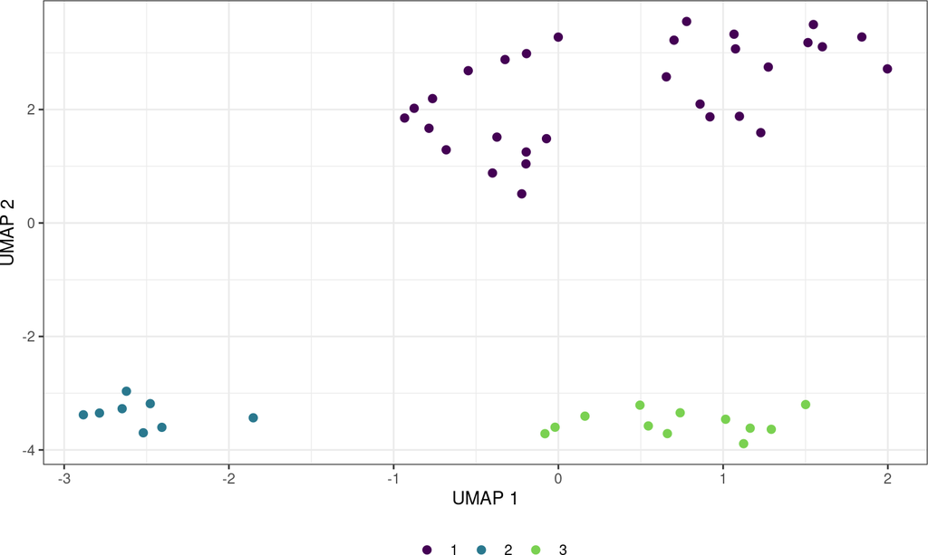